# NonLinearRegression

** Simulating a single predictor and a nonlinear relationship, such as a sin wave shown below, also investigating the relationship between the cost, epsilon and kernel parameters for a support vector machine model:**

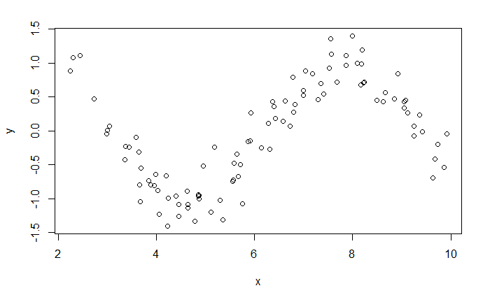

**Fitting different models using a radial basis function and different values of the cost (the C parameter). Also we have plotted the fitted curve**

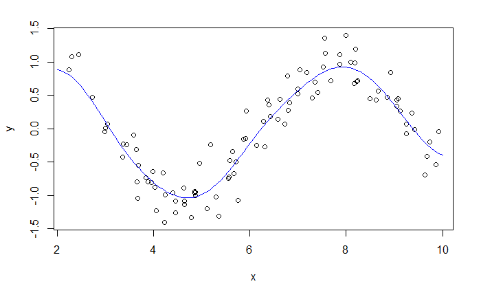

**Running a grid search with diffrent values of epsilon and cost values:**

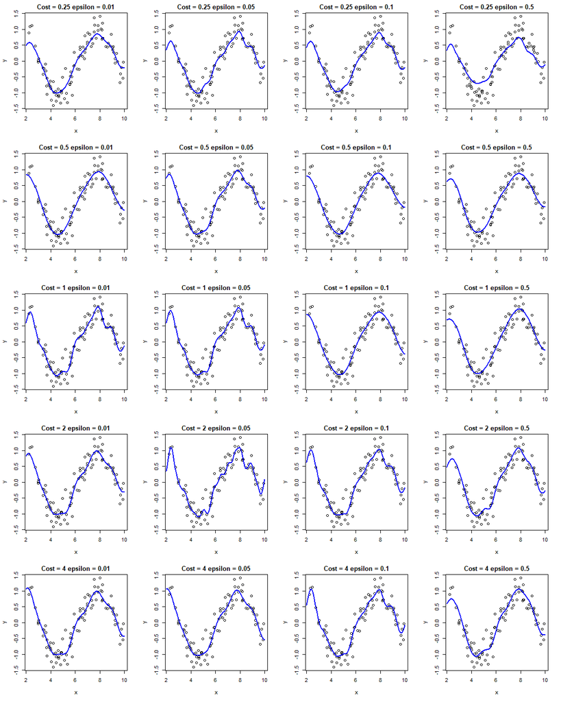

**For Tecator data - lets build SVM, neural network, MARS, and KNN models. Since neural networks are especially sensitive to highly correlated predictors, we might have to do some pre-processing using PCA**

*Support Vector Machines:*

```
Support Vector Machines with Radial Basis Function Kernel

174 samples
100 predictors

Pre-processing: centered (100), scaled (100)
Resampling: Repeated Train/Test Splits Estimated (25 reps, 75%)
Summary of sample sizes: 131, 131, 131, 131, 131, 131, ...
Resampling results across tuning parameters:

  C        RMSE      Rsquared   MAE
     0.25  9.067839  0.6036024  7.049623
     0.50  7.449927  0.6992390  5.664483
     1.00  6.333052  0.7667034  4.589118
     2.00  5.605384  0.8117571  3.973798
     4.00  5.088991  0.8423040  3.579202
     8.00  4.838371  0.8569013  3.387232
    16.00  4.702717  0.8640369  3.239728
    32.00  4.665023  0.8666517  3.176496
    64.00  4.696929  0.8648395  3.194846
   128.00  4.698819  0.8647178  3.196393
   256.00  4.698819  0.8647178  3.196393
   512.00  4.698819  0.8647178  3.196393
  1024.00  4.698819  0.8647178  3.196393
  2048.00  4.698819  0.8647178  3.196393

Tuning parameter 'sigma' was held constant at a value of 0.167782
RMSE was used to select the optimal model using the smallest value.
The final values used for the model were sigma = 0.167782 and C = 32.
```

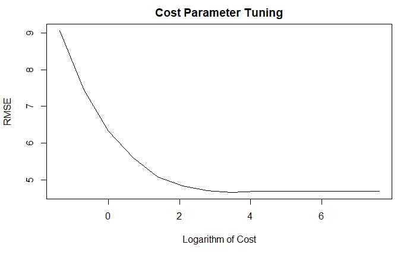

The final model selected for SVM is as shown below:

```
Support Vector Machine object of class "ksvm"

SV type: eps-svr  (regression)
 parameter : epsilon = 0.1  cost C = 32

Gaussian Radial Basis kernel function.
 Hyperparameter : sigma =  0.167782033870511

Number of Support Vectors : 114

Objective Function Value : -120.1505
Training error : 0.008022
```

The RMSE and R-Squared Values are as shown below:

```
     RMSE  Rsquared       MAE
6.8002359 0.6975258 3.9254622
```

*KNN:*

```
k-Nearest Neighbors

174 samples
100 predictors

Pre-processing: centered (100), scaled (100)
Resampling: Repeated Train/Test Splits Estimated (25 reps, 75%)
Summary of sample sizes: 131, 131, 131, 131, 131, 131, ...
Resampling results across tuning parameters:

  k   RMSE       Rsquared   MAE
   1   8.598549  0.6163770  5.891256
   2   8.009852  0.6302681  5.925643
   3   8.397831  0.5890115  6.212535
   4   8.608774  0.5674404  6.434107
   5   8.713697  0.5587431  6.650955
   6   8.650839  0.5705162  6.752913
   7   8.724156  0.5676704  6.923018
   8   8.909037  0.5494966  7.105341
   9   9.058757  0.5372679  7.267572
  10   9.267030  0.5155867  7.394406
  11   9.383537  0.5045838  7.523600
  12   9.538766  0.4877402  7.671547
  13   9.706112  0.4669650  7.820893
  14   9.823127  0.4517599  7.943753
  15   9.928493  0.4388675  8.019055
  16   9.991089  0.4322266  8.062345
  17  10.098877  0.4185541  8.144794
  18  10.222251  0.4041849  8.253896
  19  10.316552  0.3926322  8.350828
  20  10.394505  0.3818931  8.419569

RMSE was used to select the optimal model using the smallest value.
The final value used for the model was k = 2.
```

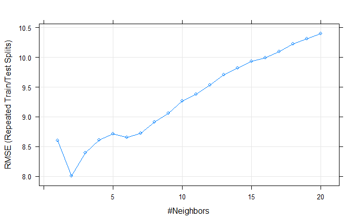

```
2-nearest neighbor regression model
```

```
     RMSE  Rsquared       MAE
7.7990979 0.6064021 5.5508130
```

*MARS:*

```
Multivariate Adaptive Regression Spline

174 samples
100 predictors

No pre-processing
Resampling: Repeated Train/Test Splits Estimated (25 reps, 75%)
Summary of sample sizes: 131, 131, 131, 131, 131, 131, ...
Resampling results across tuning parameters:

  degree  nprune  RMSE       Rsquared   MAE
  1        2      10.742716  0.3294297  8.797927
  1        3       9.787389  0.4284713  7.769813
  1        4       8.260475  0.5826573  6.507403
  1        5       4.769782  0.8766157  3.525627
```

[output cut: 73 more lines]

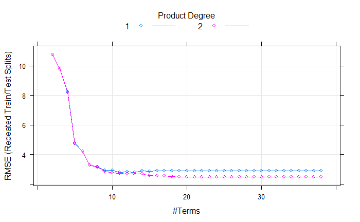

```
Selected 19 of 22 terms, and 10 of 100 predictors
Termination condition: RSq changed by less than 0.001 at 22 terms
Importance: V22, V39, V48, V11, V8, V40, V99, V6, V33, V1, V2-unused, V3-unused, V4-unused, V5-unused, ...
Number of terms at each degree of interaction: 1 9 9
GCV 3.141264    RSS 295.7843    GRSq 0.9810178    RSq 0.9896086
```

RMSE and R-Squared values are:

```
      RMSE   Rsquared        MAE
45.5484015  0.8440989 39.1501545
```

*Neural Networks*

```
Model Averaged Neural Network

174 samples
100 predictors

Pre-processing: centered (100), scaled (100)
Resampling: Repeated Train/Test Splits Estimated (25 reps, 75%)
Summary of sample sizes: 131, 131, 131, 131, 131, 131, ...
Resampling results:

  RMSE       Rsquared   MAE
  0.6390851  0.9976153  0.460784

Tuning parameter 'size' was held constant at a value of 4
Tuning parameter 'decay' was held constant at
 a value of 0.01
Tuning parameter 'bag' was held constant at a value of FALSE
```

```
Model Averaged Neural Network with 5 Repeats

a 100-4-1 network with 409 weights
options were - linear output units  decay=0.01
```

RMSE and R-Squared values are:

```
     RMSE  Rsquared       MAE
2.7567629 0.9512264 2.2870860
```

**Neural Nets model after removing highly correlated predictors**

```
Model Averaged Neural Network

174 samples
100 predictors

Pre-processing: centered (100), scaled (100), principal component signal extraction (100)
Resampling: Repeated Train/Test Splits Estimated (25 reps, 75%)
Summary of sample sizes: 131, 131, 131, 131, 131, 131, ...
Resampling results:

  RMSE      Rsquared   MAE
  10.88676  0.3229714  8.537947

Tuning parameter 'size' was held constant at a value of 4
Tuning parameter 'decay' was held constant at
 a value of 0.01
Tuning parameter 'bag' was held constant at a value of FALSE
```

```
Model Averaged Neural Network with 5 Repeats

a 2-4-1 network with 17 weights
options were - linear output units  decay=0.01
```

RMSE and R-Squared values are:

```
      RMSE   Rsquared        MAE
17.2435344  0.2590716 14.9116300
```

**Return to the permeability problem outlined in Exercise 6.2. Train several nonlinear regression models and evaluate the resampling and test set performance.**

**(a) Which nonlinear regression model gives the optimal resampling and test set performance?**

```
Support Vector Machines with Radial Basis Function Kernel

133 samples
388 predictors

Pre-processing: centered (388), scaled (388)
Resampling: Repeated Train/Test Splits Estimated (25 reps, 75%)
Summary of sample sizes: 101, 101, 101, 101, 101, 101, ...
Resampling results across tuning parameters:

  C        RMSE      Rsquared   MAE
     0.25  12.19122  0.4547874  7.969475
     0.50  11.43878  0.4637227  7.513294
     1.00  11.21301  0.4673782  7.460931
     2.00  10.96700  0.4827541  7.429800
     4.00  10.81923  0.4971212  7.479457
     8.00  10.69387  0.5046545  7.518020
    16.00  10.61926  0.5041659  7.540747
    32.00  10.63857  0.5035683  7.593684
    64.00  10.71029  0.5005337  7.659621
   128.00  10.71083  0.5014030  7.655973
   256.00  10.71074  0.5014046  7.655971
   512.00  10.71085  0.5014018  7.655977
  1024.00  10.71087  0.5014006  7.655958
  2048.00  10.71072  0.5014077  7.655881

Tuning parameter 'sigma' was held constant at a value of 0.001767135
RMSE was used to select the optimal model using the smallest value.
The final values used for the model were sigma = 0.001767135 and C = 16.
```

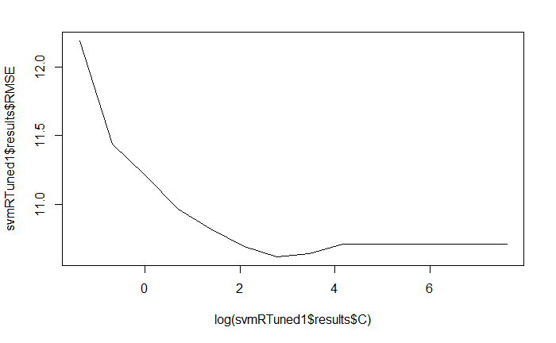

The final model selected for SVM is as shown below:

```
Support Vector Machine object of class "ksvm"

SV type: eps-svr  (regression)
 parameter : epsilon = 0.1  cost C = 16

Gaussian Radial Basis kernel function.
 Hyperparameter : sigma =  0.00176713511713268

Number of Support Vectors : 105

Objective Function Value : -195.8802
Training error : 0.033301
```

The RMSE and R-Squared Values are as shown below:

```
     RMSE  Rsquared       MAE
9.5930662 0.6845081 6.8081298
```

*KNN:*

```
k-Nearest Neighbors

133 samples
388 predictors

Pre-processing: centered (388), scaled (388)
Resampling: Repeated Train/Test Splits Estimated (25 reps, 75%)
Summary of sample sizes: 101, 101, 101, 101, 101, 101, ...
Resampling results across tuning parameters:

  k   RMSE      Rsquared   MAE
   1  13.17560  0.3811525  8.494734
   2  12.26154  0.3936062  8.073457
   3  12.12005  0.3994464  8.096451
   4  12.17467  0.3858428  8.194339
   5  12.21934  0.3772316  8.219046
   6  12.16660  0.3777723  8.150111
   7  12.09885  0.3838456  8.084201
   8  12.00881  0.3939545  8.055990
   9  11.91925  0.3998454  8.066897
  10  11.84309  0.4099669  8.113766
  11  11.86087  0.4070749  8.204484
  12  11.90136  0.4044844  8.250899
  13  12.02988  0.3935720  8.353103
  14  12.06781  0.3916180  8.432741
  15  12.15807  0.3857743  8.552452
  16  12.21772  0.3811504  8.640822
  17  12.33284  0.3737835  8.813970
  18  12.29402  0.3778016  8.855425
  19  12.35719  0.3711941  8.980061
  20  12.45551  0.3656791  9.128683

RMSE was used to select the optimal model using the smallest value.
The final value used for the model was k = 10.
```

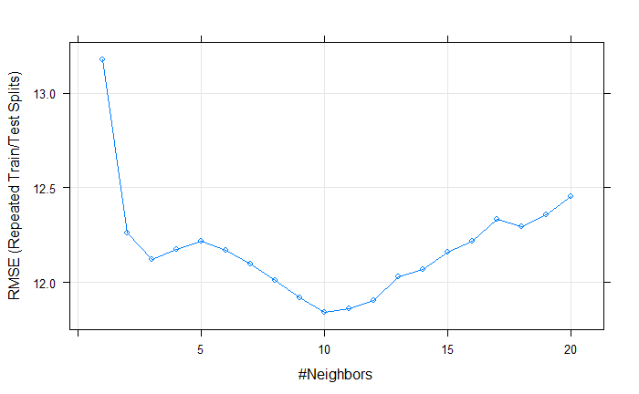

```
10-nearest neighbor regression model
```

```
     RMSE  Rsquared       MAE
12.967354  0.399433  9.717984
```

*MARS:*

```
Multivariate Adaptive Regression Spline

133 samples
388 predictors

No pre-processing
Resampling: Repeated Train/Test Splits Estimated (25 reps, 75%)
Summary of sample sizes: 101, 101, 101, 101, 101, 101, ...
Resampling results across tuning parameters:

  degree  nprune  RMSE      Rsquared   MAE
  1        2      12.15380  0.3747095   8.567520
  1        3      10.77946  0.5038947   7.194772
  1        4      11.07326  0.4747632   7.402051
  1        5      11.07456  0.4775652   7.477761
```

[output cut: 73 more lines]

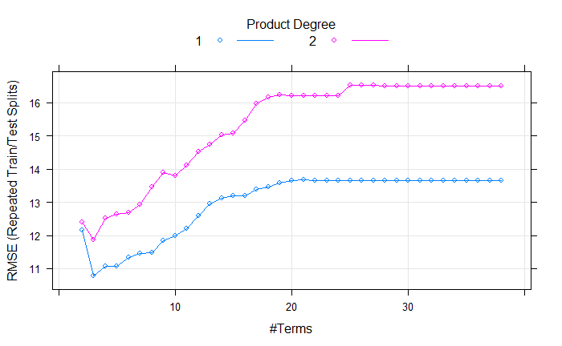

```
Selected 3 of 59 terms, and 2 of 388 predictors
Termination condition: GRSq -10 at 59 terms
Importance: X157, X6, X1-unused, X2-unused, X3-unused, X4-unused, X5-unused, X11-unused, X12-unused, ...
Number of terms at each degree of interaction: 1 2 (additive model)
GCV 121.9467    RSS 15022.37    GRSq 0.4871679    RSq 0.5177777
```

RMSE and R-Squared values are:

```
      RMSE   Rsquared        MAE
21.4066490  0.3862334 14.0203853
```